# STATS 769 Lab 04

## The data

The data are trips on electric scooters and bikes in Austin, Texas. The data came in several forms

- 10 JSON files containing 10,000 trips each. Here is the first trip.

```
{
    "trip_id": "000000cb-78a9-4b95-8ead-37c797abcf37",
    "device_id": "ad14e63b-940d-4ca3-84c6-0131147fba45",
    "vehicle_type": "scooter",
    "trip_duration": "358",
    "trip_distance": "915",
    "start_time": "2018-06-29T17:30:00.000",
    "end_time": "2018-06-29T17:30:00.000",
    "modified_date": "2019-04-17T08:18:38.000",
    "month": "6",
    "hour": "17",
    "day_of_week": "5",
    "council_district_start": "5",
    "council_district_end": "9",
    "year": "2018",
    "census_geoid_start": "48453001303",
    "census_geoid_end": "48453001305"
}
```

- A MongoDB database containing 100,000 trips (with the same structure as the JSON files).
- 10 XML files containing 10,000 trips each. Here is the first trip.

```
<row _id="row-k9c6~ns9i~iqjb" _uuid="00000000-0000-0000-76F0-AB56BEE9C7CA" _position="0" _address="https://data.austintexas.gov/resource/_7d8e-dm7r/000000cb-78a9-4b95-8ead-37c797abcf37">
  <trip_id>000000cb-78a9-4b95-8ead-37c797abcf37</trip_id>
  <device_id>ad14e63b-940d-4ca3-84c6-0131147fba45</device_id>
  <vehicle_type>scooter</vehicle_type>
  <trip_duration>358</trip_duration>
  <trip_distance>915</trip_distance>
  <start_time>2018-06-29T17:30:00</start_time>
  <end_time>2018-06-29T17:30:00</end_time>
  <modified_date>2019-04-17T08:18:38</modified_date>
  <month>6</month>
  <hour>17</hour>
  <day_of_week>5</day_of_week>
  <council_district_start>5</council_district_start>
  <council_district_end>9</council_district_end>
  <year>2018</year>
  <census_geoid_start>48453001303</census_geoid_start>
  <census_geoid_end>48453001305</census_geoid_end>
</row>
```

## Data Import

Reading individual JSON files into R is straightforward with the ‘jsonlite’ package because the result is immediately a data frame.

```r
library(jsonlite)
trips1json <- fromJSON(readLines("/course/Labs/Lab04/JSON/trips-1.json"))
dim(trips1json)
```

```
[1] 10000    16
```

```r
names(trips1json)
```

```
 [1] "trip_id"                "device_id"
 [3] "vehicle_type"           "trip_duration"
 [5] "trip_distance"          "start_time"
 [7] "end_time"               "modified_date"
 [9] "month"                  "hour"
[11] "day_of_week"            "council_district_start"
[13] "council_district_end"   "year"
[15] "census_geoid_start"     "census_geoid_end"
```

```r
trips1json[1, c("trip_distance", "trip_duration")]
```

```
  trip_distance trip_duration
1           915           358
```

The following code reads all 10 JSON files in, combines them to create a single data frame, and then extracts just the scooter trips from 2018.

```r
filesJSON <- list.files("/course/Labs/Lab04/JSON", pattern="trips-.*.json",
                        full.names=TRUE)
tripsJSON <- do.call(rbind,
                     lapply(filesJSON, function(x) fromJSON(readLines(x))))
scooterTrips2018json <- subset(tripsJSON,
                               year == 2018 & vehicle_type == "scooter",
                               c("trip_duration", "trip_distance"))
scooterTrips2018json$trip_duration <-
    as.numeric(scooterTrips2018json$trip_duration)
scooterTrips2018json$trip_distance <-
    as.numeric(scooterTrips2018json$trip_distance)
dim(scooterTrips2018json)
```

```
[1] 98817     2
```

Reading data from the MongoDB database using the ‘mongolite’ package means that we can just extract the subset of the data that we want.  
We do not have to read the entire data set into R. Again, the result is immediately an R data frame.

```r
library(mongolite)
m <- mongo("trips")
scooterTrips2018mongo <-
    m$find(query='{ "year": "2018", "vehicle_type": "scooter" }',
           fields='{ "_id": 0, "trip_duration": 1, "trip_distance": 1 }')
dim(scooterTrips2018mongo)
```

```
[1] 98817     2
```

Reading data from individual XML files is also straightforward with the ‘xml2’ package, though the result is not an R data frame.

```r
library(xml2)
trips1xml <- read_xml("/course/Labs/Lab04/XML/trips-1.xml")
xml_find_first(trips1xml, "//row")
```

```
{xml_node}
<row _id="row-k9c6~ns9i~iqjb" _uuid="00000000-0000-0000-76F0-AB56BEE9C7CA" _position="0" _address="https://data.austintexas.gov/resource/_7d8e-dm7r/000000cb-78a9-4b95-8ead-37c797abcf37">
 [1] <trip_id>000000cb-78a9-4b95-8ead-37c797abcf37</trip_id>
 [2] <device_id>ad14e63b-940d-4ca3-84c6-0131147fba45</device_id>
 [3] <vehicle_type>scooter</vehicle_type>
 [4] <trip_duration>358</trip_duration>
 [5] <trip_distance>915</trip_distance>
 [6] <start_time>2018-06-29T17:30:00</start_time>
 [7] <end_time>2018-06-29T17:30:00</end_time>
 [8] <modified_date>2019-04-17T08:18:38</modified_date>
 [9] <month>6</month>
[10] <hour>17</hour>
[11] <day_of_week>5</day_of_week>
[12] <council_district_start>5</council_district_start>
[13] <council_district_end>9</council_district_end>
[14] <year>2018</year>
[15] <census_geoid_start>48453001303</census_geoid_start>
[16] <census_geoid_end>48453001305</census_geoid_end>
```

We have to extract trip distance and trip duration values from the result.

```r
as.numeric(xml_text(xml_find_first(trips1xml, "//trip_duration")))
```

```
[1] 358
```

```r
as.numeric(xml_text(xml_find_first(trips1xml, "//trip_distance")))
```

```
[1] 915
```

The following code reads all 10 XML files, extracts the trip duration and distance for scooter trips in 2018 and combines the result into a data frame. The XPath used to extract the information identifies the `trip_distance` and `trip_duration` elements anywhere within the XML document then adds a predicate that checks for a preceding sibling `vehicle_type` element with content `"scooter"` and a following sibling `year` with content `"2018"`.

```r
filesXML <- list.files("/course/Labs/Lab04/XML", pattern="trips-.*.xml",
                        full.names=TRUE)
predicate <- "preceding-sibling::vehicle_type[text() = 'scooter'] and
              following-sibling::year[text() = '2018']"
distancePath <- paste0("//trip_distance[", predicate, "]")
durationPath <- paste0("//trip_duration[", predicate, "]")
scooterTrips2018xml <-
    do.call(rbind,
            lapply(filesXML,
                   function(x) {
                       xml <- read_xml(x)
                       distance <- xml_text(xml_find_all(xml, distancePath))
                       duration <- xml_text(xml_find_all(xml, durationPath))
                       data.frame(trip_duration=as.numeric(duration),
                                  trip_distance=as.numeric(distance))
                   }))
dim(scooterTrips2018xml)
```

```
[1] 98817     2
```

If we use BaseX to query the XML files all at once, we can just extract the XML values that we want before reading them into R. The following Xquery code loops over all `row` elements with XML files in the `/course/Labs?Lab04/XML/` directory, selects those rows that have a `vehicle_type` child with content `"scooter"` *and* a `year` child with content `"2018"`, then returns the content of `trip_duration` and `trip_distance` children, separated by a comma.

It is also ok to do this in two queries, one to return `trip_duration` and one to return `trip_distance` (that makes the return clause a lot simpler).

```bash
cat query.xq
```

```
for $i in collection("file:///course/Labs/Lab04/XML")//row
    where $i/vehicle_type[text() = 'scooter'] and
          $i/year[text() = '2018']
    return string-join(($i/trip_duration/text(), $i/trip_distance/text()), ',')
```

If we run the XQuery with BaseX …

```bash
basex query.xq > trips-xquery.csv
```

… we get a CSV file …

```bash
head -6 trips-xquery.csv
```

```
278,0
158,543
285,430
1880,2482
71,233
207,197
```

… that we can just read the CSV file into R as usual.

```r
scooterTrips2018xquery <- read.csv("trips-xquery.csv", header=FALSE,
                                   col.names=c("trip_duration",
                                               "trip_distance"))
dim(scooterTrips2018xquery)
```

```
[1] 98817     2
```

The following code checks that all four methods have produced exactly the same data frame in R (ignoring order of rows).

```r
all(scooterTrips2018json == scooterTrips2018mongo &
    scooterTrips2018json == scooterTrips2018xml &
    scooterTrips2018json[order(scooterTrips2018json$trip_duration,
                               scooterTrips2018json$trip_distance), ] ==
    scooterTrips2018xquery[order(scooterTrips2018xquery$trip_duration,
                                 scooterTrips2018xquery$trip_distance), ])
```

```
[1] TRUE
```

## R processing

Now that we have a data frame containing 98817 trip durations and distances, we will subset non-negative values and log both variables in preparation for fitting models.

```r
trips <- subset(scooterTrips2018json, trip_duration > 0 & trip_distance > 0)
tripDuration <- log(trips$trip_duration)
tripDistance <- log(trips$trip_distance)
```

This leaves us with 85644 trips to analyse.

## Choosing a polynomial regression model

We will now reuse code from the previous lab to fit a series of polynomial regression models. First we generate a set of group labels.

```r
labels <- rep(1:10, length.out=length(tripDuration))
groups <- sample(labels)
```

Next, we define a function to calculate MSE for one “fold” of the data.

```r
mse <- function(i, formula) {
    testSet <- groups == i
    trainSet <- groups != i
    fit <- lm(formula,
              data.frame(x=tripDistance[trainSet], y=tripDuration[trainSet]))
    pred <- predict(fit, data.frame(x=tripDistance[testSet]))
    mean((pred - tripDuration[testSet])^2)
}
```

The following code collects test MSE estimates for 5 models.

```r
MSE <- vector("list", 5)
MSE[[1]] <- sapply(1:10, mse, y ~ x)
MSE[[2]] <- sapply(1:10, mse, y ~ x + I(x^2))
MSE[[3]] <- sapply(1:10, mse, y ~ x + I(x^2) + I(x^3))
MSE[[4]] <- sapply(1:10, mse, y ~ x + I(x^2) + I(x^3) + I(x^4))
MSE[[5]] <- sapply(1:10, mse, y ~ x + I(x^2) + I(x^3) + I(x^4) + I(x^5))
```

If we plot those MSE estimates and join up their average values with a line, we see that the models improve with increasing power up to a point (around a power of 3 or 4). The large variability in the power 2 model is notable; we will come back to that later.

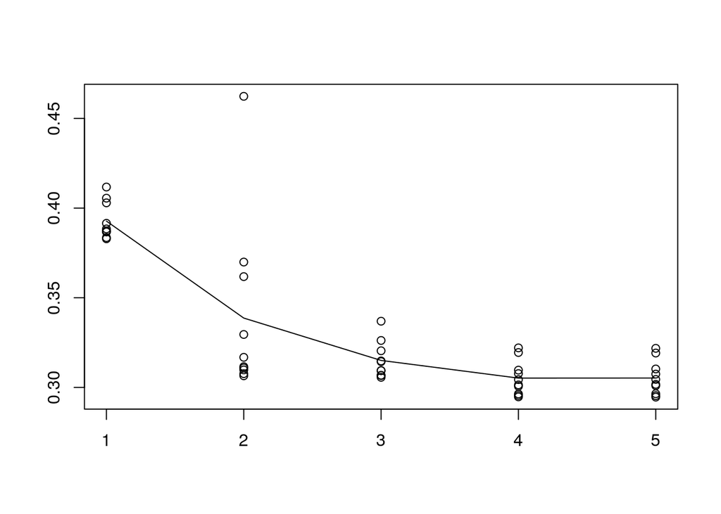

```r
plot.new()
plot.window(c(1, 5), range(unlist(MSE)))
for (i in 1:5) {
    points(rep(i, 10), MSE[[i]])
}
lines(1:5, sapply(MSE, mean))
box()
axis(1)
axis(2)
```

The following code generates predictions from each model using the full data and plots the prediction lines on top of a scatterplot of the raw data. There are two interesting features: as expected, the higher powers produce more flexile lines; and there are trip distance outliers that are having a large influence on the model fits.

The higher power models are capable of fitting very closely to the distance outliers. This is hampering the power 3 model from doing a better job at small trip distances. This may also explain the high variability of test MSE estimates for the power 2 model; the trained model may vary quite a lot depending on whether the training set contains these distance outliers.

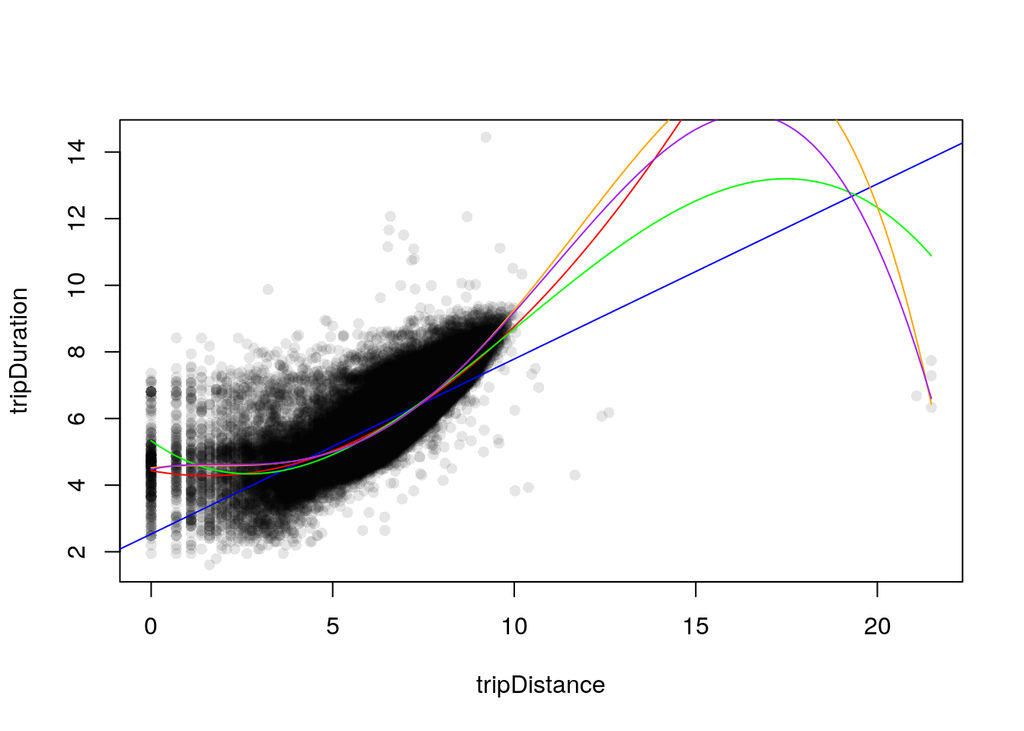

```r
lmFit <- lm(y ~ x, data.frame(x=tripDistance, y=tripDuration))
polyFit2 <- lm(y ~ x + I(x^2),
               data.frame(x=tripDistance, y=tripDuration))
polyFit3 <- lm(y ~ x + I(x^2) + I(x^3),
               data.frame(x=tripDistance, y=tripDuration))
polyFit4 <- lm(y ~ x + I(x^2) + I(x^3) + I(x^4),
               data.frame(x=tripDistance, y=tripDuration))
polyFit5 <- lm(y ~ x + I(x^2) + I(x^3) + I(x^4) + I(x^5),
               data.frame(x=tripDistance, y=tripDuration))
dummyX <- seq(0, max(tripDistance), length.out=100)
polyPred2 <- predict(polyFit2, data.frame(x=dummyX))
polyPred3 <- predict(polyFit3, data.frame(x=dummyX))
polyPred4 <- predict(polyFit4, data.frame(x=dummyX))
polyPred5 <- predict(polyFit5, data.frame(x=dummyX))
plot(tripDistance, tripDuration, pch=16, col=rgb(0,0,0,.1))
abline(lmFit, col="blue")
lines(dummyX, polyPred2, col="red")
lines(dummyX, polyPred3, col="green")
lines(dummyX, polyPred4, col="orange")
lines(dummyX, polyPred5, col="purple")
```

I should probably discard the trip distance outliers and repeat the modelling process (wI should probably have spotted and dealt with the outliers before we began modelling!), but I have left them in because they provide an interesting demonstration of the different impact of outliers on the different models AND they show the value of plotting the data in addition to calculating simple numerical measures of model goodness like estimating the test error (we get a much better and more detailed idea of how well the model is fitting the data).

## Conclusion

The data came in both JSON and XML formats for this lab, which we handled as raw JSON, via a MongoDB database, as raw XML, and via XQuery request with BaseX. All approaches produced exactly the same data set.

We only dealt with non-negative trip durations and distances and logged both variables.

We used k-fold cross-validation to estimate test error for a range of polynomial regressions models (up to degree 5) and that suggested that a degree 3 or 4 polynomial would be adequate.

Belated plots of the data showed that our model fits may have been badly influenced by some trip distance outliers and a degree 3 model may be all that we really need to capture the main trend in the data.